# Red Wine’s Qualities Exploration By CHEN XINRUI

This report explores a dataset containing qualities and 11 attributes for approximately 1600 red wine samples.

# Univariate Plots Section

```
## [1] 1599   12
```

```
## 'data.frame':    1599 obs. of  12 variables:
##  $ fixed.acidity       : num  7.4 7.8 7.8 11.2 7.4 7.4 7.9 7.3 7.8 7.5 ...
##  $ volatile.acidity    : num  0.7 0.88 0.76 0.28 0.7 0.66 0.6 0.65 0.58 0.5 ...
##  $ citric.acid         : num  0 0 0.04 0.56 0 0 0.06 0 0.02 0.36 ...
##  $ residual.sugar      : num  1.9 2.6 2.3 1.9 1.9 1.8 1.6 1.2 2 6.1 ...
##  $ chlorides           : num  0.076 0.098 0.092 0.075 0.076 0.075 0.069 0.065 0.073 0.071 ...
##  $ free.sulfur.dioxide : num  11 25 15 17 11 13 15 15 9 17 ...
##  $ total.sulfur.dioxide: num  34 67 54 60 34 40 59 21 18 102 ...
##  $ density             : num  0.998 0.997 0.997 0.998 0.998 ...
##  $ pH                  : num  3.51 3.2 3.26 3.16 3.51 3.51 3.3 3.39 3.36 3.35 ...
##  $ sulphates           : num  0.56 0.68 0.65 0.58 0.56 0.56 0.46 0.47 0.57 0.8 ...
##  $ alcohol             : num  9.4 9.8 9.8 9.8 9.4 9.4 9.4 10 9.5 10.5 ...
##  $ quality             : int  5 5 5 6 5 5 5 7 7 5 ...
```

```
##  fixed.acidity   volatile.acidity  citric.acid    residual.sugar
##  Min.   : 4.60   Min.   :0.1200   Min.   :0.000   Min.   : 0.900
##  1st Qu.: 7.10   1st Qu.:0.3900   1st Qu.:0.090   1st Qu.: 1.900
##  Median : 7.90   Median :0.5200   Median :0.260   Median : 2.200
##  Mean   : 8.32   Mean   :0.5278   Mean   :0.271   Mean   : 2.539
##  3rd Qu.: 9.20   3rd Qu.:0.6400   3rd Qu.:0.420   3rd Qu.: 2.600
##  Max.   :15.90   Max.   :1.5800   Max.   :1.000   Max.   :15.500
##    chlorides       free.sulfur.dioxide total.sulfur.dioxide
##  Min.   :0.01200   Min.   : 1.00       Min.   :  6.00
##  1st Qu.:0.07000   1st Qu.: 7.00       1st Qu.: 22.00
##  Median :0.07900   Median :14.00       Median : 38.00
##  Mean   :0.08747   Mean   :15.87       Mean   : 46.47
##  3rd Qu.:0.09000   3rd Qu.:21.00       3rd Qu.: 62.00
##  Max.   :0.61100   Max.   :72.00       Max.   :289.00
##     density             pH          sulphates         alcohol
##  Min.   :0.9901   Min.   :2.740   Min.   :0.3300   Min.   : 8.40
##  1st Qu.:0.9956   1st Qu.:3.210   1st Qu.:0.5500   1st Qu.: 9.50
##  Median :0.9968   Median :3.310   Median :0.6200   Median :10.20
##  Mean   :0.9967   Mean   :3.311   Mean   :0.6581   Mean   :10.42
##  3rd Qu.:0.9978   3rd Qu.:3.400   3rd Qu.:0.7300   3rd Qu.:11.10
##  Max.   :1.0037   Max.   :4.010   Max.   :2.0000   Max.   :14.90
##     quality
##  Min.   :3.000
##  1st Qu.:5.000
##  Median :6.000
##  Mean   :5.636
##  3rd Qu.:6.000
##  Max.   :8.000
```

Our dataset consists of 12 variables, with almost 1600 observations.

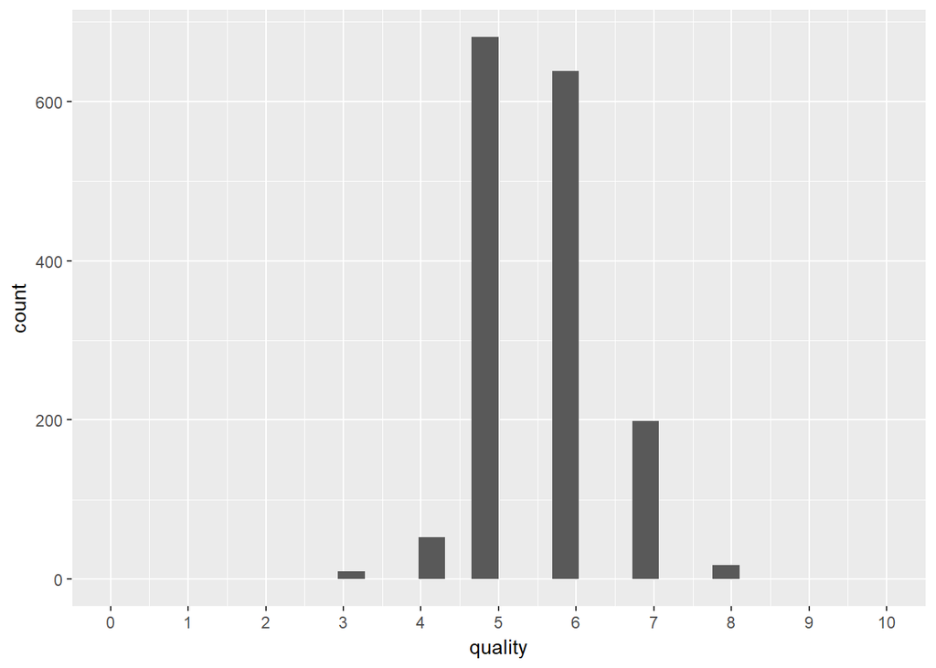

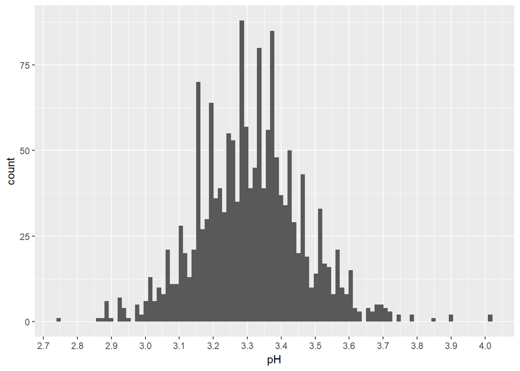

```
##
## 2.74 2.86 2.87 2.88 2.89  2.9 2.92 2.93 2.94 2.95 2.98 2.99    3 3.01 3.02
##    1    1    1    2    4    1    4    3    4    1    5    2    6    5    8
## 3.03 3.04 3.05 3.06 3.07 3.08 3.09  3.1 3.11 3.12 3.13 3.14 3.15 3.16 3.17
##    6   10    8   10   11   11   11   19    9   20   13   21   34   36   27
## 3.18 3.19  3.2 3.21 3.22 3.23 3.24 3.25 3.26 3.27 3.28 3.29  3.3 3.31 3.32
##   30   25   39   36   39   32   29   26   53   35   42   46   57   39   45
## 3.33 3.34 3.35 3.36 3.37 3.38 3.39  3.4 3.41 3.42 3.43 3.44 3.45 3.46 3.47
##   37   43   39   56   37   48   48   37   34   33   17   29   20   22   21
## 3.48 3.49  3.5 3.51 3.52 3.53 3.54 3.55 3.56 3.57 3.58 3.59  3.6 3.61 3.62
##   19   10   14   15   18   17   16    8   11   10   10    8    7    8    4
## 3.63 3.66 3.67 3.68 3.69  3.7 3.71 3.72 3.74 3.75 3.78 3.85  3.9 4.01
##    3    4    3    5    4    1    4    3    1    1    2    1    2    2
```

```
##    Min. 1st Qu.  Median    Mean 3rd Qu.    Max.
##   2.740   3.210   3.310   3.311   3.400   4.010
```

From above, it can be seen that most wines are between 3-4 on the pH scale. Wines all contain some extent of acid. There is some wine at pH beyond 3.7 or below 2.9, which is extreme. I’d like to explore how these wine perform at quality further.

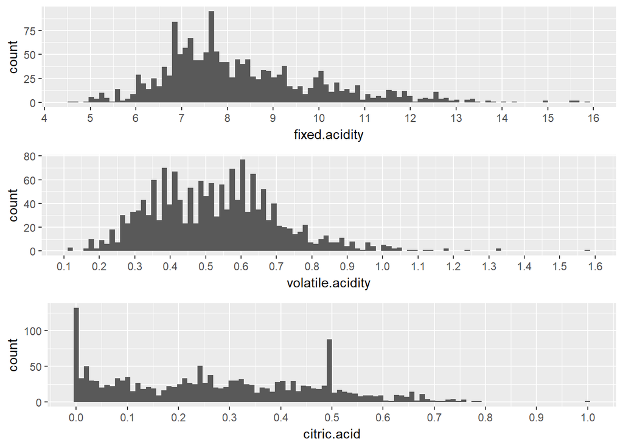

We can see most acids involved with wine are fixed. Volatile acidity is relatively low,because too high of levels can lead to an unpleasant, vinegar taste.Citric acid is found in smallest quantities. Interestingly, apart from 0, there is another peak around 0.5 in citric.acid. All these should be relative to pH value,which I’d find out soon.

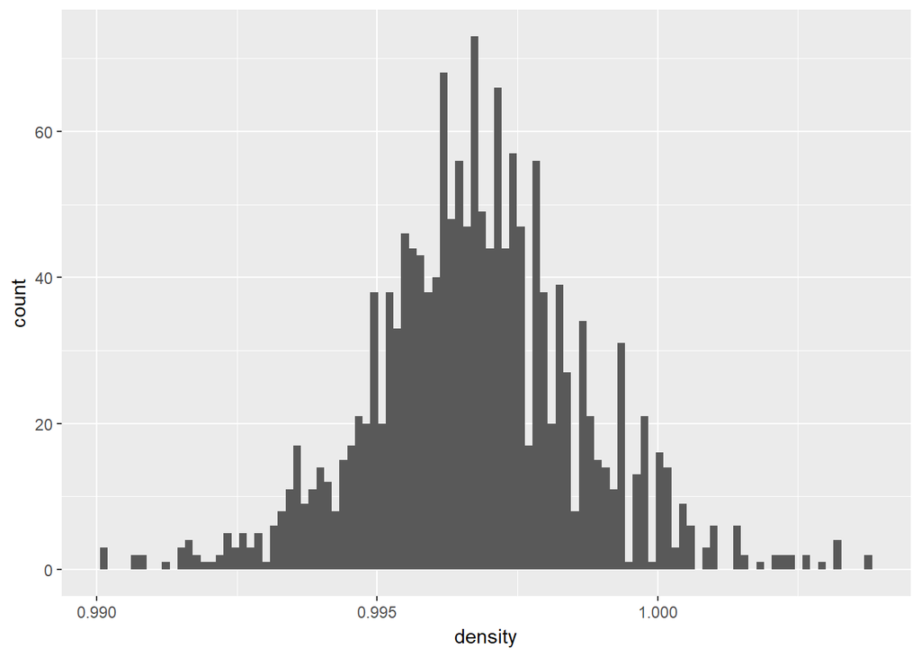

```
##    Min. 1st Qu.  Median    Mean 3rd Qu.    Max.
##  0.9901  0.9956  0.9968  0.9967  0.9978  1.0037
```

The density of wine is close to that of water but a little lower because of the percent of alcohol and sugar content. The peak is around 0.997. I’d like to explore the relationship among density, alcohol and sugar later.

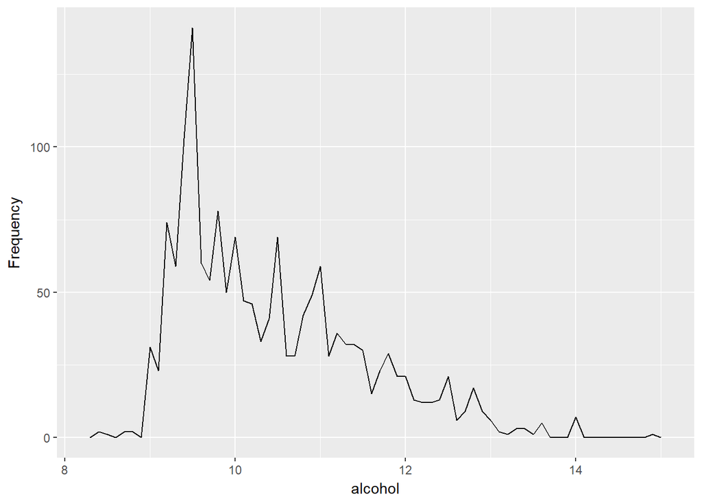

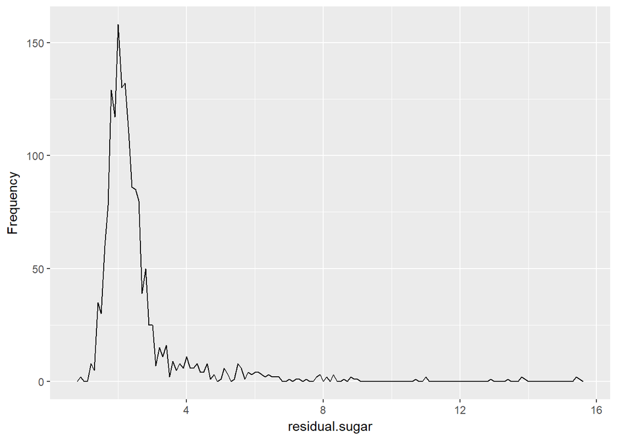

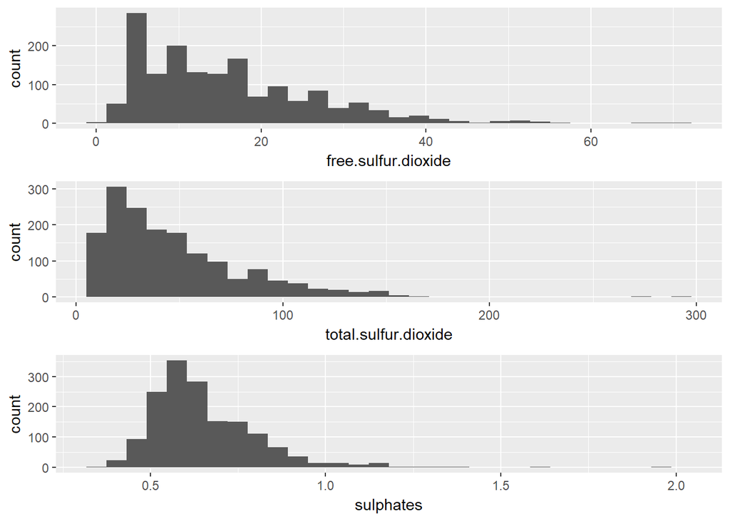

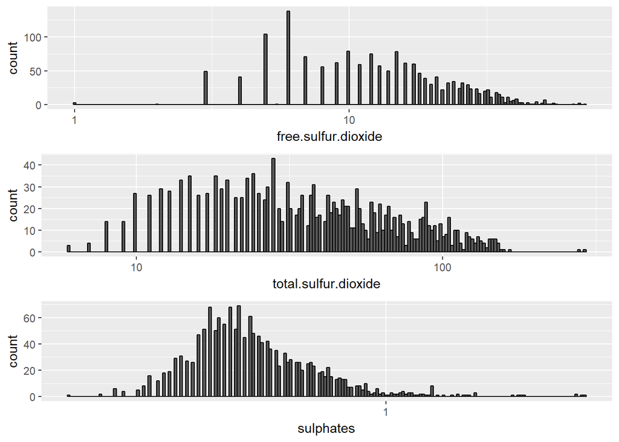

The origin histogram is skewed so I transform the data using a log transform. Both free.sulfur.dioxide and total.sulfur.dioxide are integers. There are some exceptions in free sulfur dioxide at around 50 and in sulphates as well. I wonder how these contribute to the qualities.

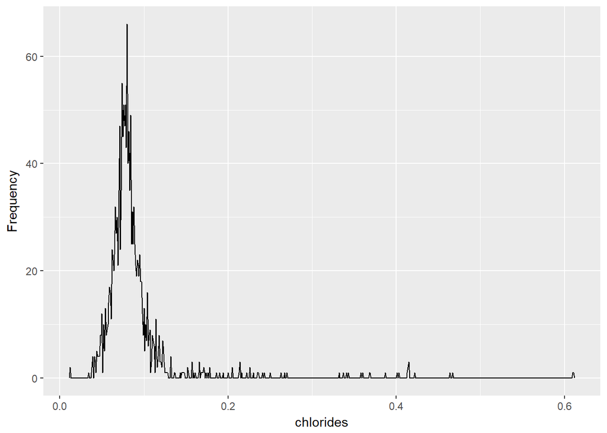

```
## [1] 0
```

The dataset has no missing value,as a result, it’s trusted.

# Univariate Analysis

### What is the structure of your dataset?

There are 1599 observations of 12 varibles in the wine quality dataset. It has 11 input attributes including pH, density, fixed.acidity, volatile.acidity, citric.acid, residual.sugar, chlorides free.sulfur.dioxide, total.sulfur.dioxide, sulphates, alcohol and one output attribute quality,which depends on input attributes.

Other observations: All qualities are around intermediate level,within(3,8). Most wines are between 3-4 on the pH scale. The median density is 0.9968.

### What is/are the main feature(s) of interest in your dataset?

The main features in the dataset are pH,density,free sulfur dioxide and quality. I’d like to determine which features are best for predicting the quality of a wine. I suspect pH, density,free sulfur dioxide and some combination of the other variables can be used to build a predictive model to wine quality.

### What other features in the dataset do you think will help support your investigation into your feature(s) of interest?

Acidity,sugar,alcohol and chloride all likely contribute to the quality.

### Did you create any new variables from existing variables in the dataset?

No.

### Of the features you investigated, were there any unusual distributions? Did you perform any operations on the data to tidy, adjust, or change the form of the data? If so, why did you do this?

There are some exceptions in citric acid and sulphates distributions. The origin histograms of sulfur dioxide are skewed so I transform the data using a log transform.

# Bivariate Plots Section

```
##                      fixed.acidity volatile.acidity citric.acid
## fixed.acidity                 1.00            -0.26        0.67
## volatile.acidity             -0.26             1.00       -0.55
## citric.acid                   0.67            -0.55        1.00
## residual.sugar                0.11             0.00        0.14
## chlorides                     0.09             0.06        0.20
## free.sulfur.dioxide          -0.15            -0.01       -0.06
## total.sulfur.dioxide         -0.11             0.08        0.04
## density                       0.67             0.02        0.36
## pH                           -0.68             0.23       -0.54
## sulphates                     0.18            -0.26        0.31
## alcohol                      -0.06            -0.20        0.11
##                      residual.sugar chlorides free.sulfur.dioxide
## fixed.acidity                  0.11      0.09               -0.15
## volatile.acidity               0.00      0.06               -0.01
## citric.acid                    0.14      0.20               -0.06
## residual.sugar                 1.00      0.06                0.19
## chlorides                      0.06      1.00                0.01
## free.sulfur.dioxide            0.19      0.01                1.00
## total.sulfur.dioxide           0.20      0.05                0.67
## density                        0.36      0.20               -0.02
## pH                            -0.09     -0.27                0.07
## sulphates                      0.01      0.37                0.05
## alcohol                        0.04     -0.22               -0.07
##                      total.sulfur.dioxide density    pH sulphates alcohol
## fixed.acidity                       -0.11    0.67 -0.68      0.18   -0.06
## volatile.acidity                     0.08    0.02  0.23     -0.26   -0.20
## citric.acid                          0.04    0.36 -0.54      0.31    0.11
## residual.sugar                       0.20    0.36 -0.09      0.01    0.04
## chlorides                            0.05    0.20 -0.27      0.37   -0.22
## free.sulfur.dioxide                  0.67   -0.02  0.07      0.05   -0.07
## total.sulfur.dioxide                 1.00    0.07 -0.07      0.04   -0.21
## density                              0.07    1.00 -0.34      0.15   -0.50
## pH                                  -0.07   -0.34  1.00     -0.20    0.21
## sulphates                            0.04    0.15 -0.20      1.00    0.09
## alcohol                             -0.21   -0.50  0.21      0.09    1.00
```

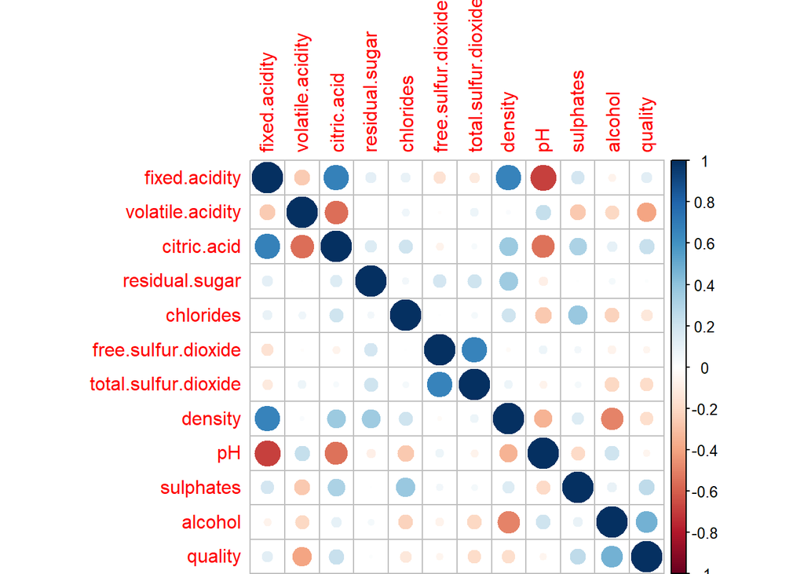

From above, I found out: 1.pH is strongly negatively associated with fixed and citric acidity. 2.Density is strongly associated with fixed acidity, partly with citric acid and reresidual sugar and negatively with alcohol. 3.Fixed acidity is associated with citric acid.Volatile acid is strongly negatively associated with citric acid. 4.free and total sulfur dioxide are closely related. 5.Sulphates partly related with chlorides but not related with sulfur dioxide. 6.Quality seems coorlate with alcohol and volatile acidity a lot.

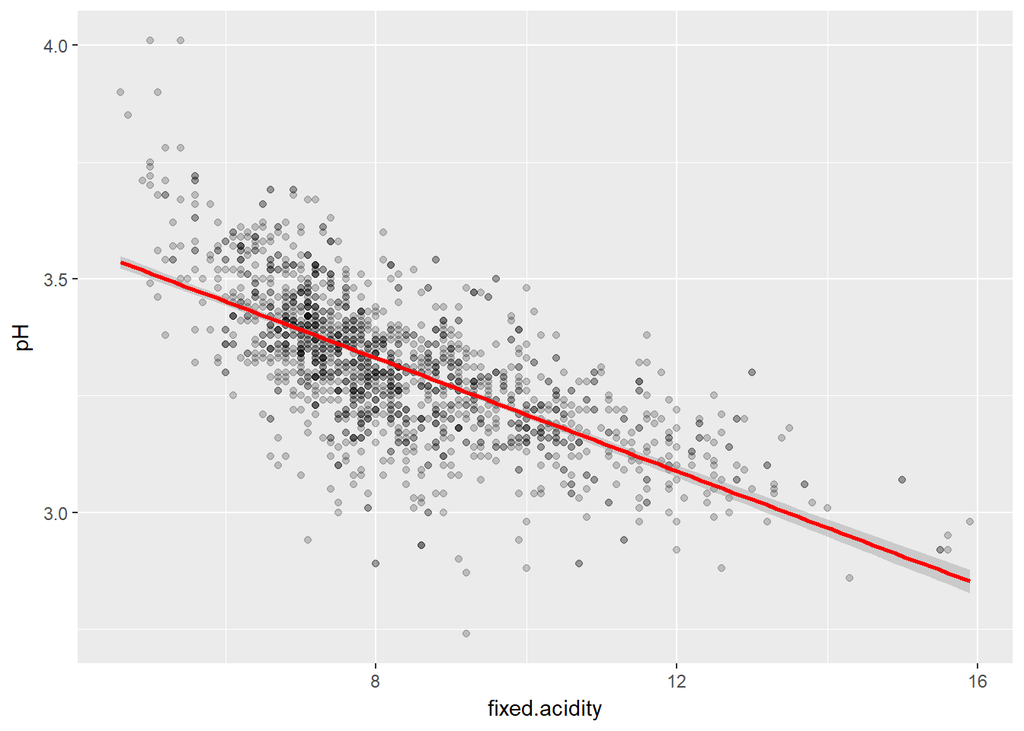

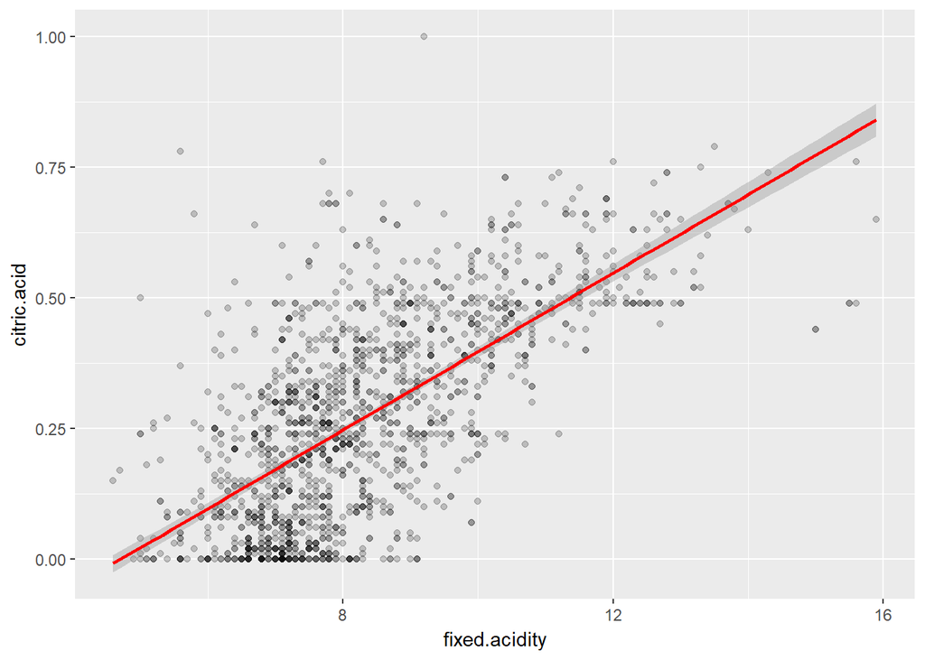

```
##
##  Pearson's product-moment correlation
##
## data:  wine$fixed.acidity and wine$citric.acid
## t = 36.234, df = 1597, p-value < 2.2e-16
## alternative hypothesis: true correlation is not equal to 0
## 95 percent confidence interval:
##  0.6438839 0.6977493
## sample estimates:
##       cor
## 0.6717034
```

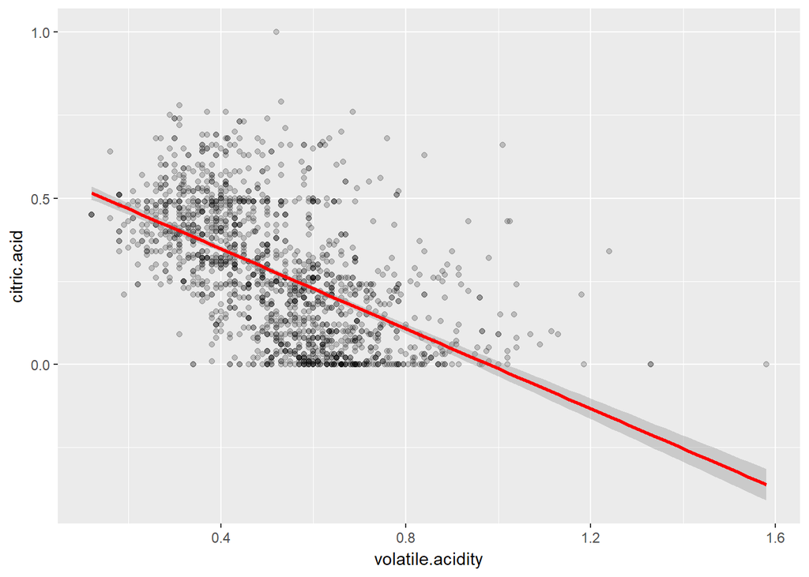

```
##
##  Pearson's product-moment correlation
##
## data:  wine$volatile.acidity and wine$citric.acid
## t = -26.489, df = 1597, p-value < 2.2e-16
## alternative hypothesis: true correlation is not equal to 0
## 95 percent confidence interval:
##  -0.5856550 -0.5174902
## sample estimates:
##        cor
## -0.5524957
```

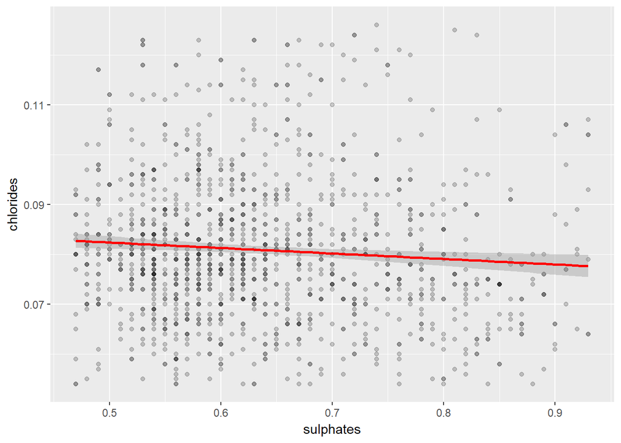

Then,I’d like to find out attributes’ influences on quality.

```
##
##  Pearson's product-moment correlation
##
## data:  wine$quality and wine$alcohol
## t = 21.639, df = 1597, p-value < 2.2e-16
## alternative hypothesis: true correlation is not equal to 0
## 95 percent confidence interval:
##  0.4373540 0.5132081
## sample estimates:
##       cor
## 0.4761663
```

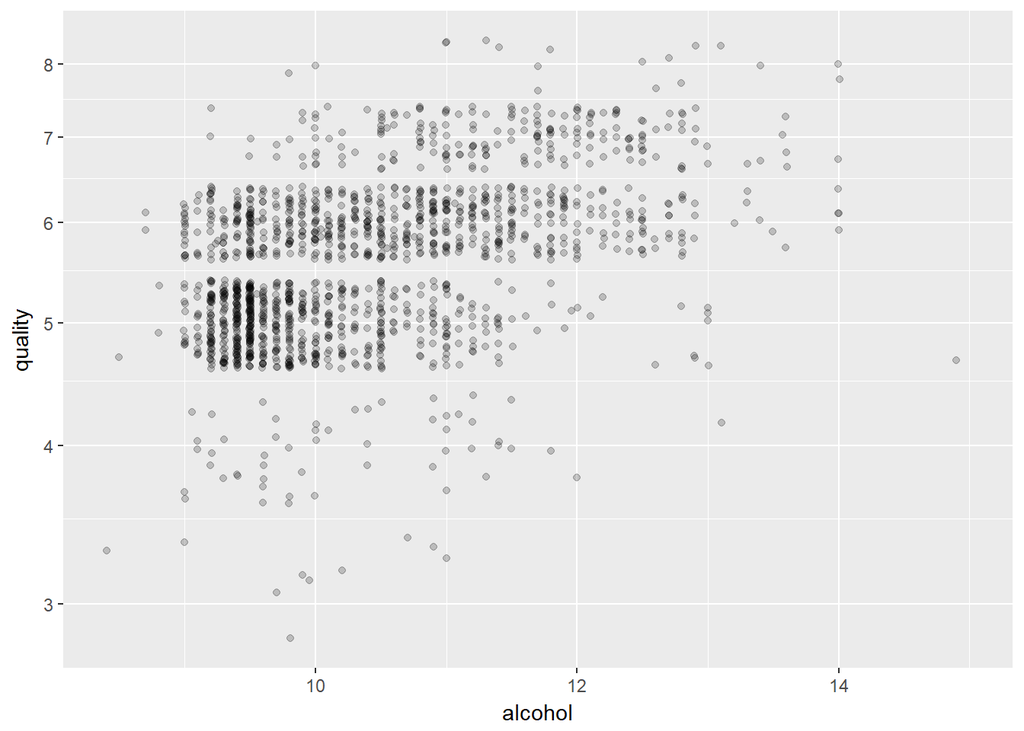

I cannot fully understand this plot,so I will make some changes later.

```
## # A tibble: 6 x 4
##   quality al_mean almedian     n
##     <int>   <dbl>    <dbl> <int>
## 1       3    9.96     9.93    10
## 2       4   10.3     10.0     53
## 3       5    9.90     9.70   681
## 4       6   10.6     10.5    638
## 5       7   11.5     11.5    199
## 6       8   12.1     12.2     18
```

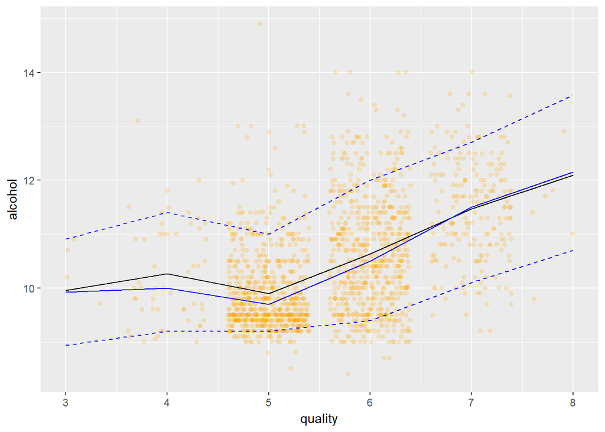

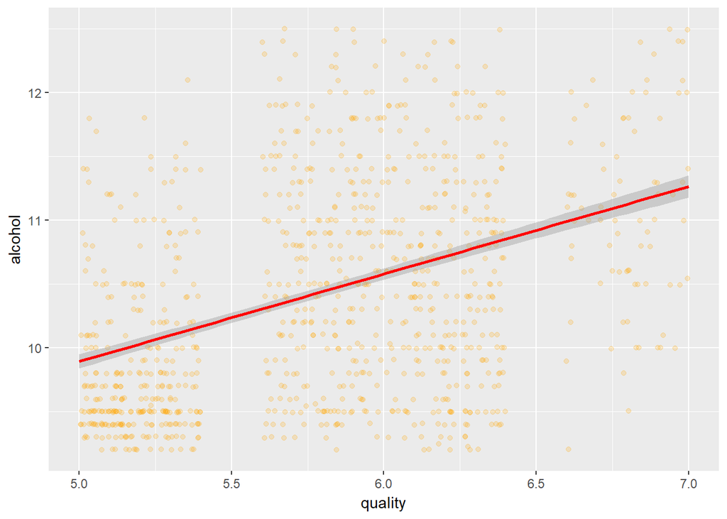

After removing some outliers, it becomes more clear.When alcohol level improves, the quality has a tendency to improve.There seems a linear relationship between them. Then I will boxplot to better analyze ordinal level variable like quality.

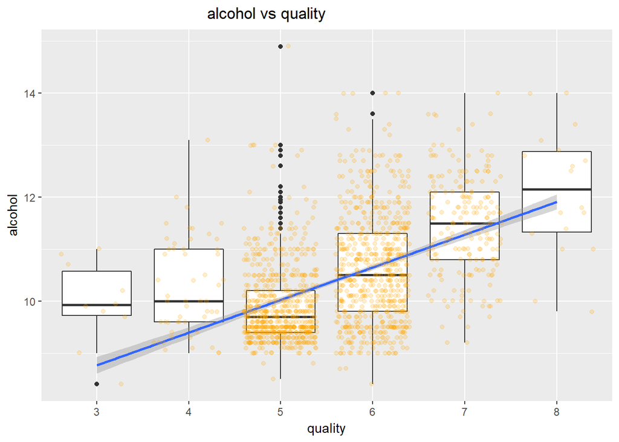

```
##
##  Pearson's product-moment correlation
##
## data:  wine$quality and wine$volatile.acidity
## t = -16.954, df = 1597, p-value < 2.2e-16
## alternative hypothesis: true correlation is not equal to 0
## 95 percent confidence interval:
##  -0.4313210 -0.3482032
## sample estimates:
##        cor
## -0.3905578
```

```
## # A tibble: 6 x 4
##   quality vola_mean volamedian     n
##     <int>     <dbl>      <dbl> <int>
## 1       3     0.884      0.845    10
## 2       4     0.694      0.670    53
## 3       5     0.577      0.580   681
## 4       6     0.497      0.490   638
## 5       7     0.404      0.370   199
## 6       8     0.423      0.370    18
```

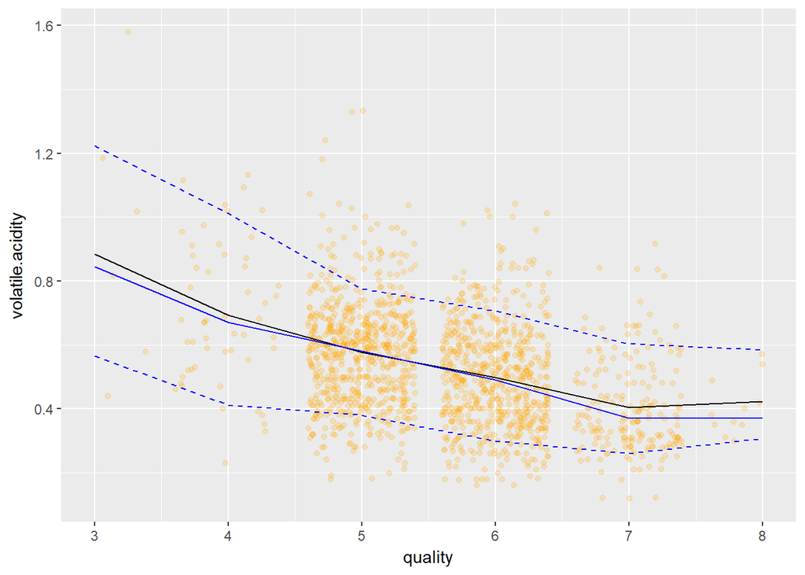

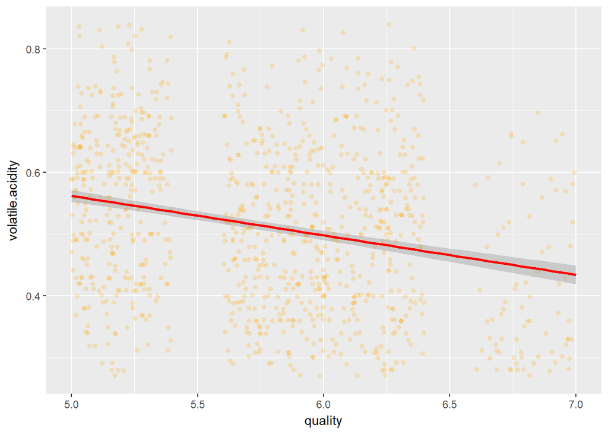

When volatile acidity level improves, the quality has a tendency to decrease.But the relationship is not very high. Again,I will boxplot to better analyze ordinal level variable like quality.

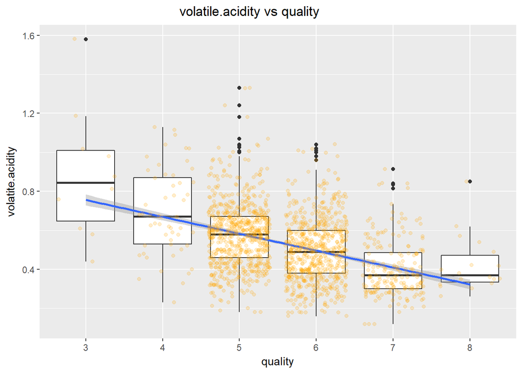

Next,I’d like to explore citric acid and sulphate. They have a slighter relationship with quality.

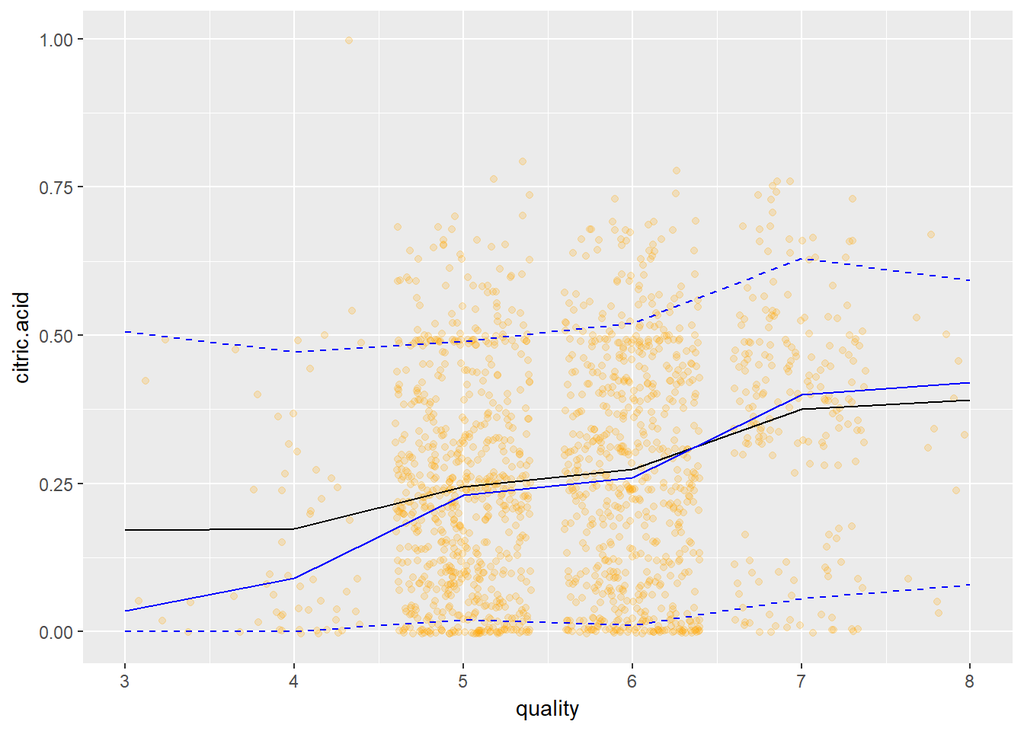

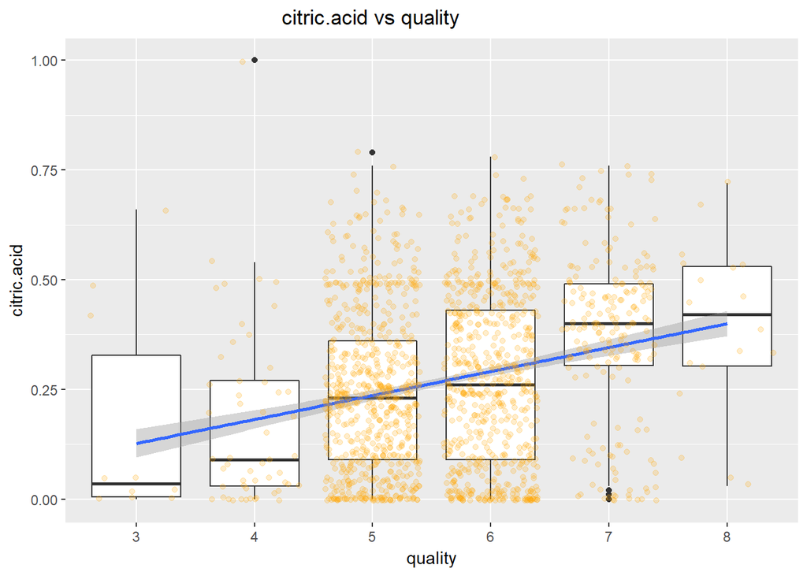

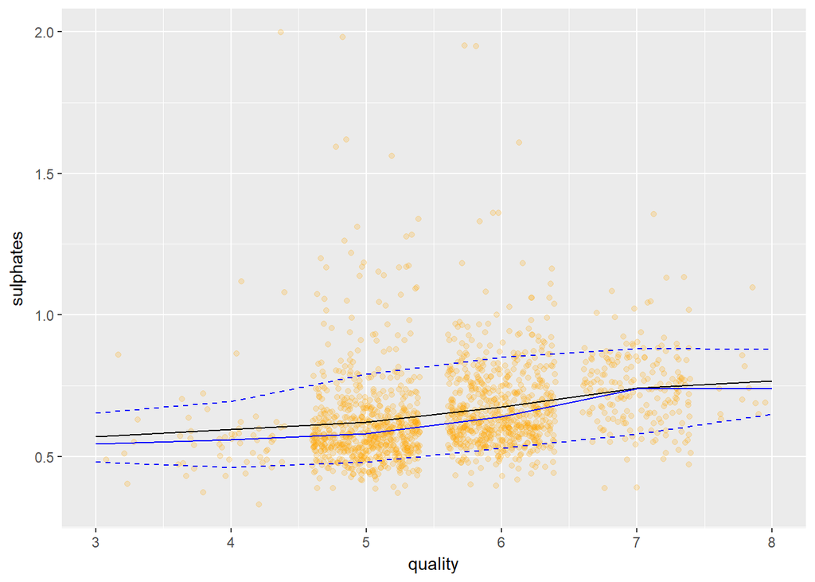

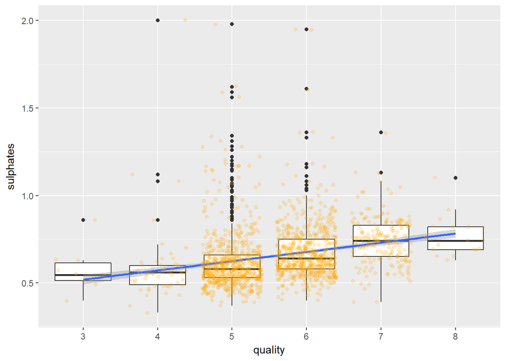

# Bivariate Analysis

### Talk about some of the relationships you observed in this part of the investigation. How did the feature(s) of interest vary with other features in the dataset?

1.pH is strongly negatively associated with fixed and citric acidity. 2.Density is strongly associated with fixed acidity, partly with citric acid and reresidual sugar and negatively with alcohol. 3.Free sulfur dioxide and total sulfur dioxide are closely related.

### Did you observe any interesting relationships between the other features (not the main feature(s) of interest)?

1.Fixed acidity is associated with citric acid.Volatile acid is strongly negatively associated with citric acid. 2.Sulphates partly related with chlorides but not related with sulfur dioxide. 3.Quality seems coorlate with alcohol and volatile acidity a lot. When volatile acidity level improves, the quality has a tendency to decrease.When alcohol level improves, the quality has a tendency to improve.

### What was the strongest relationship you found?

pH is strongly negatively associated with fixed acidity.

# Multivariate Plots Section

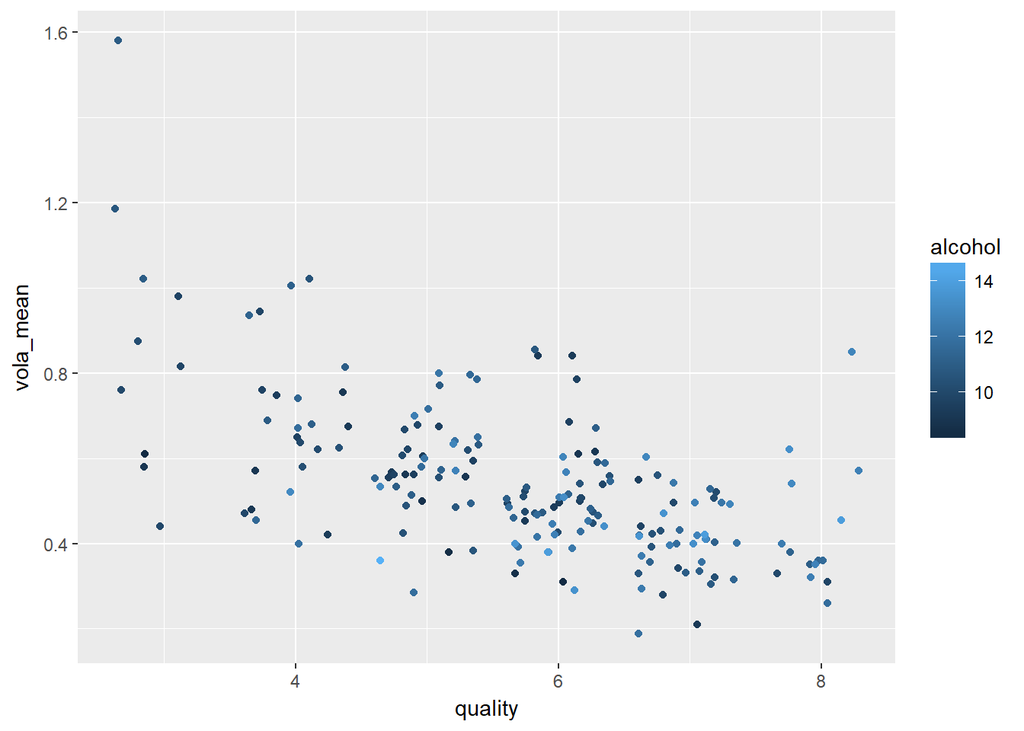

[figure not shown]

From abloe,we can see that both alcohol and volatile acidity count a lot. Either of them’s problem might cause quality problem.

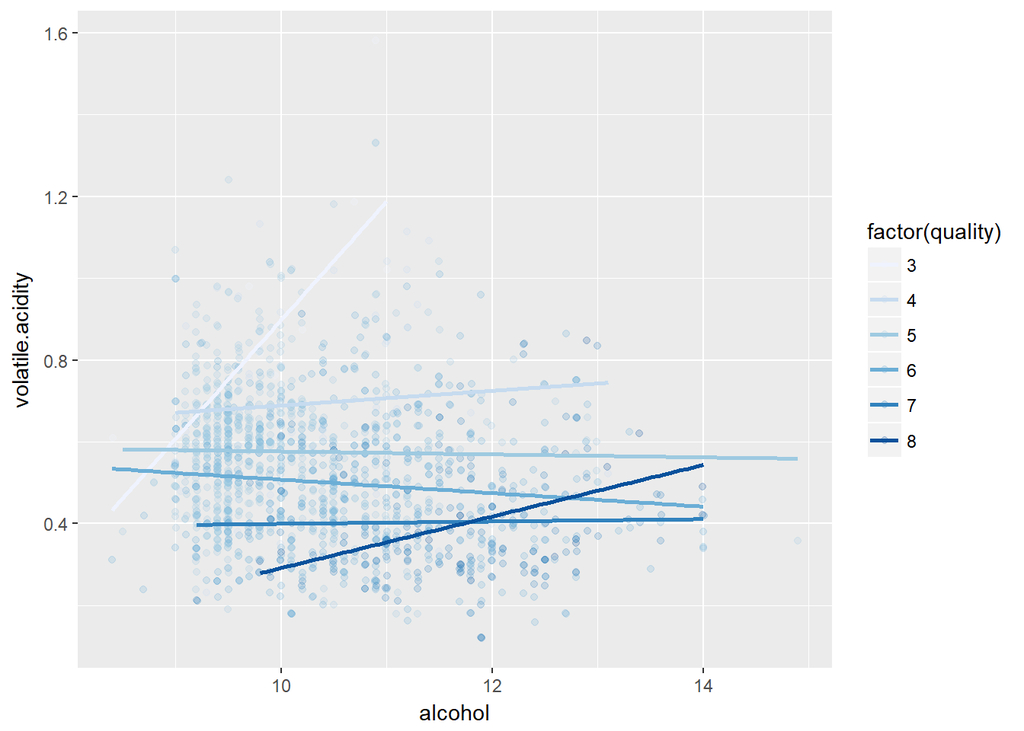

When the alcohol concentration is low, the quality is not high regardless of the change of the volatile acid, and when the volatile acid is relatively high, the quality is not high regardless of the alcohol concentration. Only in both the better range, the quality will be better.

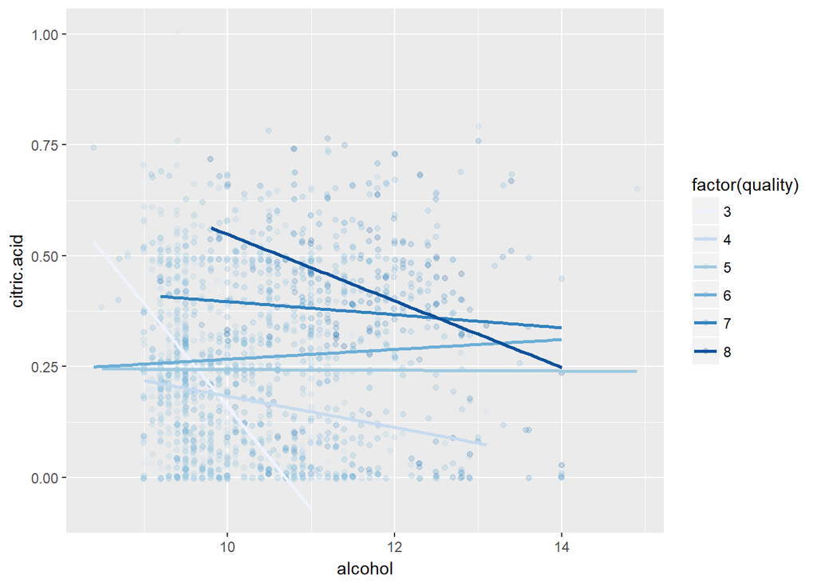